# Question 2

gowtham_1p23mb010

2025-02-02

Question No: 02

Using the “Marketing Customer Value Analysis” dataset, complete the following tasks with proper analysis and interpretation:

1. Load the dataset and explore its structure using basic commands.

```r
library(ggplot2)
```

```r
df=read.csv("D:/Data Science for Marketing-I/data/WA_Fn-UseC_-Marketing-Customer-Value-Analysis.csv")
```

```r
head(df)
```

```
##   Customer      State Customer.Lifetime.Value Response Coverage Education
## 1  BU79786 Washington                2763.519       No    Basic  Bachelor
## 2  QZ44356    Arizona                6979.536       No Extended  Bachelor
## 3  AI49188     Nevada               12887.432       No  Premium  Bachelor
## 4  WW63253 California                7645.862       No    Basic  Bachelor
## 5  HB64268 Washington                2813.693       No    Basic  Bachelor
## 6  OC83172     Oregon                8256.298      Yes    Basic  Bachelor
##   Effective.To.Date EmploymentStatus Gender Income Location.Code Marital.Status
## 1           2/24/11         Employed      F  56274      Suburban        Married
## 2           1/31/11       Unemployed      F      0      Suburban         Single
## 3           2/19/11         Employed      F  48767      Suburban        Married
## 4           1/20/11       Unemployed      M      0      Suburban        Married
## 5            2/3/11         Employed      M  43836         Rural         Single
## 6           1/25/11         Employed      F  62902         Rural        Married
##   Monthly.Premium.Auto Months.Since.Last.Claim Months.Since.Policy.Inception
```

[output cut: 20 more lines]

```r
str(df)
```

```
## 'data.frame':    9134 obs. of  24 variables:
##  $ Customer                     : chr  "BU79786" "QZ44356" "AI49188" "WW63253" ...
##  $ State                        : chr  "Washington" "Arizona" "Nevada" "California" ...
##  $ Customer.Lifetime.Value      : num  2764 6980 12887 7646 2814 ...
##  $ Response                     : chr  "No" "No" "No" "No" ...
##  $ Coverage                     : chr  "Basic" "Extended" "Premium" "Basic" ...
##  $ Education                    : chr  "Bachelor" "Bachelor" "Bachelor" "Bachelor" ...
##  $ Effective.To.Date            : chr  "2/24/11" "1/31/11" "2/19/11" "1/20/11" ...
##  $ EmploymentStatus             : chr  "Employed" "Unemployed" "Employed" "Unemployed" ...
##  $ Gender                       : chr  "F" "F" "F" "M" ...
##  $ Income                       : int  56274 0 48767 0 43836 62902 55350 0 14072 28812 ...
##  $ Location.Code                : chr  "Suburban" "Suburban" "Suburban" "Suburban" ...
##  $ Marital.Status               : chr  "Married" "Single" "Married" "Married" ...
##  $ Monthly.Premium.Auto         : int  69 94 108 106 73 69 67 101 71 93 ...
##  $ Months.Since.Last.Claim      : int  32 13 18 18 12 14 0 0 13 17 ...
##  $ Months.Since.Policy.Inception: int  5 42 38 65 44 94 13 68 3 7 ...
##  $ Number.of.Open.Complaints    : int  0 0 0 0 0 0 0 0 0 0 ...
##  $ Number.of.Policies           : int  1 8 2 7 1 2 9 4 2 8 ...
##  $ Policy.Type                  : chr  "Corporate Auto" "Personal Auto" "Personal Auto" "Corporate Auto" ...
##  $ Policy                       : chr  "Corporate L3" "Personal L3" "Personal L3" "Corporate L2" ...
##  $ Renew.Offer.Type             : chr  "Offer1" "Offer3" "Offer1" "Offer1" ...
##  $ Sales.Channel                : chr  "Agent" "Agent" "Agent" "Call Center" ...
##  $ Total.Claim.Amount           : num  385 1131 566 530 138 ...
##  $ Vehicle.Class                : chr  "Two-Door Car" "Four-Door Car" "Two-Door Car" "SUV" ...
##  $ Vehicle.Size                 : chr  "Medsize" "Medsize" "Medsize" "Medsize" ...
```

```r
summary(df)
```

```
##    Customer            State           Customer.Lifetime.Value
##  Length:9134        Length:9134        Min.   : 1898
##  Class :character   Class :character   1st Qu.: 3994
##  Mode  :character   Mode  :character   Median : 5780
##                                        Mean   : 8005
##                                        3rd Qu.: 8962
##                                        Max.   :83325
##    Response           Coverage          Education         Effective.To.Date
##  Length:9134        Length:9134        Length:9134        Length:9134
##  Class :character   Class :character   Class :character   Class :character
##  Mode  :character   Mode  :character   Mode  :character   Mode  :character
##
##
##
##  EmploymentStatus      Gender              Income      Location.Code
##  Length:9134        Length:9134        Min.   :    0   Length:9134
##  Class :character   Class :character   1st Qu.:    0   Class :character
##  Mode  :character   Mode  :character   Median :33890   Mode  :character
##                                        Mean   :37657
##                                        3rd Qu.:62320
##                                        Max.   :99981
##  Marital.Status     Monthly.Premium.Auto Months.Since.Last.Claim
##  Length:9134        Min.   : 61.00       Min.   : 0.0
##  Class :character   1st Qu.: 68.00       1st Qu.: 6.0
##  Mode  :character   Median : 83.00       Median :14.0
##                     Mean   : 93.22       Mean   :15.1
##                     3rd Qu.:109.00       3rd Qu.:23.0
##                     Max.   :298.00       Max.   :35.0
##  Months.Since.Policy.Inception Number.of.Open.Complaints Number.of.Policies
##  Min.   : 0.00                 Min.   :0.0000            Min.   :1.000
##  1st Qu.:24.00                 1st Qu.:0.0000            1st Qu.:1.000
##  Median :48.00                 Median :0.0000            Median :2.000
##  Mean   :48.06                 Mean   :0.3844            Mean   :2.966
##  3rd Qu.:71.00                 3rd Qu.:0.0000            3rd Qu.:4.000
##  Max.   :99.00                 Max.   :5.0000            Max.   :9.000
##  Policy.Type           Policy          Renew.Offer.Type   Sales.Channel
##  Length:9134        Length:9134        Length:9134        Length:9134
##  Class :character   Class :character   Class :character   Class :character
##  Mode  :character   Mode  :character   Mode  :character   Mode  :character
##
##
##
##  Total.Claim.Amount Vehicle.Class      Vehicle.Size
##  Min.   :   0.099   Length:9134        Length:9134
##  1st Qu.: 272.258   Class :character   Class :character
##  Median : 383.945   Mode  :character   Mode  :character
##  Mean   : 434.089
##  3rd Qu.: 547.515
##  Max.   :2893.240
```

```r
dim(df)
```

```
## [1] 9134   24
```

Interpertation: Basic commands provide an overview of the dataset.

2. Create a new column named “Engaged” by transforming the categorical values in the “Response” variable into numerical values. Why is this transformation important?

```r
df$Engaged <- ifelse(df$Response == "Yes", 1, 0)
```

Interpertation: Converts “Yes/No” responses into 1 and 0 for numerical analysis.

3. Calculate and interpret the Engagement Rate. How is it computed, and what does it indicate about the customer responses?

```r
print(sum(df$Engaged)/nrow(df)*100)
```

```
## [1] 14.32012
```

Interpertation: Engagement rate shows the percentage of customers who responded positively.

4. Analyze engagement rate by “Renew Offer Type” and “Sales Channel”:

```r
aggregate(Engaged ~ Renew.Offer.Type + Sales.Channel, data = df, mean)
```

```
##    Renew.Offer.Type Sales.Channel    Engaged
## 1            Offer1         Agent 0.19881657
## 2            Offer2         Agent 0.31901840
## 3            Offer3         Agent 0.03474903
## 4            Offer4         Agent 0.00000000
## 5            Offer1        Branch 0.15286624
## 6            Offer2        Branch 0.15989848
## 7            Offer3        Branch 0.00000000
## 8            Offer4        Branch 0.00000000
## 9            Offer1   Call Center 0.07142857
## 10           Offer2   Call Center 0.23183926
## 11           Offer3   Call Center 0.00000000
## 12           Offer4   Call Center 0.00000000
## 13           Offer1           Web 0.12800000
## 14           Offer2           Web 0.18713450
## 15           Offer3           Web 0.05240175
## 16           Offer4           Web 0.00000000
```

Interpertation: Groups data by “Renew Offer Type” and “Sales Channel” to analyze engagement patterns.

22. Use a pivot table to summarize engagement by “Renew Offer Type” and visualize the results using both bar and pie charts. Why are these visualizations helpful in understanding customer engagement patterns?

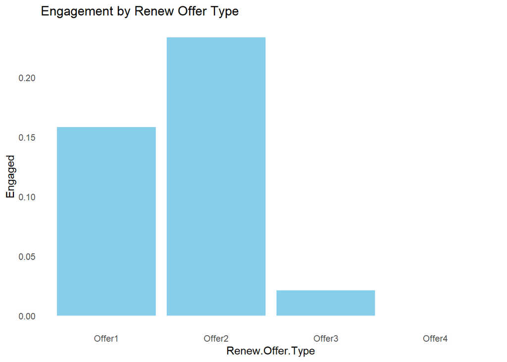

```r
#Bar chart
ggplot(df, aes(x = Renew.Offer.Type, y = Engaged)) +
  stat_summary(fun = mean, geom = "bar", fill = "skyblue") +
  ggtitle("Engagement by Renew Offer Type")+
   theme_minimal() +
  theme(panel.grid.major = element_blank(), panel.grid.minor = element_blank())
```

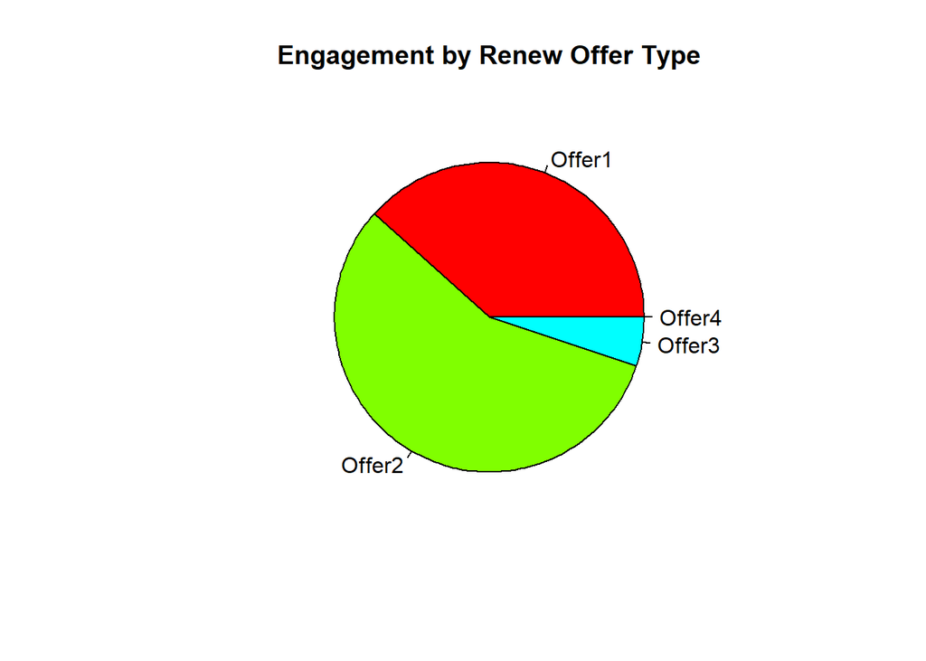

```r
# Pie chart
engagement_summary <- aggregate(Engaged ~ Renew.Offer.Type, data = df, mean)
pie(engagement_summary$Engaged, labels = engagement_summary$Renew.Offer.Type,
    main = "Engagement by Renew Offer Type", col = rainbow(length(engagement_summary$Engaged)))
```

6. Explain the purpose of regression analysis in this context. Describe how you would approach regression using

**Purpose of Regression Analysis:** Regression analysis is used to understand and quantify the relationship between variables, enabling the prediction of an outcome variable (e.g., engagement) based on other influencing factors.

1. continuous variables only

```r
# Continuous variables only
model_cont <- lm(Engaged ~ Income, data = df)
summary(model_cont)
```

```
##
## Call:
## lm(formula = Engaged ~ Income, data = df)
##
## Residuals:
##     Min      1Q  Median      3Q     Max
## -0.1518 -0.1460 -0.1417 -0.1380  0.8620
##
## Coefficients:
##              Estimate Std. Error t value Pr(>|t|)
## (Intercept) 1.380e-01  5.838e-03   23.64   <2e-16 ***
## Income      1.376e-07  1.207e-07    1.14    0.254
## ---
## Signif. codes:  0 '***' 0.001 '**' 0.01 '*' 0.05 '.' 0.1 ' ' 1
##
## Residual standard error: 0.3503 on 9132 degrees of freedom
## Multiple R-squared:  0.0001424,  Adjusted R-squared:  3.289e-05
## F-statistic:   1.3 on 1 and 9132 DF,  p-value: 0.2542
```

Interpretation: **Continuous Variables:** Examines numerical predictors to assess their direct influence on the outcome. The coefficients indicate how much the target variable changes with a one-unit increase in the predictor.

2. categorical variables

```r
# Categorical variables
df$Renew.Offer.Type <- as.factor(df$Renew.Offer.Type)
model_cat <- glm(Engaged ~ Renew.Offer.Type, family = binomial, data = df)
summary(model_cat)
```

```
##
## Call:
## glm(formula = Engaged ~ Renew.Offer.Type, family = binomial,
##     data = df)
##
## Coefficients:
##                         Estimate Std. Error z value Pr(>|z|)
## (Intercept)             -1.67081    0.04472 -37.359  < 2e-16 ***
## Renew.Offer.TypeOffer2   0.48365    0.06252   7.736 1.02e-14 ***
## Renew.Offer.TypeOffer3  -2.17364    0.18986 -11.449  < 2e-16 ***
## Renew.Offer.TypeOffer4 -16.89525  203.83246  -0.083    0.934
## ---
## Signif. codes:  0 '***' 0.001 '**' 0.01 '*' 0.05 '.' 0.1 ' ' 1
##
## (Dispersion parameter for binomial family taken to be 1)
##
##     Null deviance: 7503.3  on 9133  degrees of freedom
## Residual deviance: 6751.8  on 9130  degrees of freedom
## AIC: 6759.8
##
## Number of Fisher Scoring iterations: 17
```

Interpretation: **Categorical Variables:** Utilizes dummy coding to evaluate the impact of different categories. The coefficients signify the variation from the baseline category.

3. both continuous and categorical variables

```r
# Both types
model_both <- glm(Engaged ~ Income + Renew.Offer.Type, family = binomial, data = df)
summary(model_both)
```

```
##
## Call:
## glm(formula = Engaged ~ Income + Renew.Offer.Type, family = binomial,
##     data = df)
##
## Coefficients:
##                          Estimate Std. Error z value Pr(>|z|)
## (Intercept)            -1.700e+00  5.522e-02 -30.789  < 2e-16 ***
## Income                  9.426e-07  1.035e-06   0.911    0.362
## Renew.Offer.TypeOffer2  4.712e-01  6.399e-02   7.363 1.79e-13 ***
## Renew.Offer.TypeOffer3 -2.181e+00  1.900e-01 -11.477  < 2e-16 ***
## Renew.Offer.TypeOffer4 -1.691e+01  2.038e+02  -0.083    0.934
## ---
## Signif. codes:  0 '***' 0.001 '**' 0.01 '*' 0.05 '.' 0.1 ' ' 1
##
## (Dispersion parameter for binomial family taken to be 1)
##
##     Null deviance: 7503.3  on 9133  degrees of freedom
## Residual deviance: 6751.0  on 9129  degrees of freedom
## AIC: 6761
##
## Number of Fisher Scoring iterations: 17
```

Interpretation:**Combination of Both:** Integrates numerical and categorical variables for a comprehensive model. Continuous predictors show direct effects, while categorical variables are interpreted relative to a reference group.